# MSDS6306 Unit 4 Assignment

J Lancon

October 01, 2017

### Question 1

FiveThirtyEight Data: Navigate on GitHub to https://github.com/rudeboybert/fivethrityeight and read README.md.

#### **1.a**

Install the fivethirtyeight package:

#### **1.b**

In the listing of Data sets in package ‘fivethirtyeight,’ assign the eighteenth data set to an object ‘df’.

```r
#data(package = "fivethirtyeight")

# Assigning dataset College_recent_grads, from FiveThirtyEight to df
# Original Data from article written by Ben Casselman "The Economic Guide to Picking A College Major"

df <- fivethirtyeight::college_recent_grads
head(df,3)
```

```
##   rank major_code                          major major_category total
## 1    1       2419          Petroleum Engineering    Engineering  2339
## 2    2       2416 Mining And Mineral Engineering    Engineering   756
## 3    3       2415      Metallurgical Engineering    Engineering   856
##   sample_size  men women sharewomen employed employed_fulltime
## 1          36 2057   282  0.1205643     1976              1849
## 2           7  679    77  0.1018519      640               556
## 3           3  725   131  0.1530374      648               558
##   employed_parttime employed_fulltime_yearround unemployed
## 1               270                        1207         37
## 2               170                         388         85
## 3               133                         340         16
##   unemployment_rate p25th median  p75th college_jobs non_college_jobs
## 1        0.01838053 95000 110000 125000         1534              364
## 2        0.11724138 55000  75000  90000          350              257
## 3        0.02409639 50000  73000 105000          456              176
##   low_wage_jobs
## 1           193
## 2            50
## 3             0
```

#### **1.c**

Use a more detailed list of the data set to write out the URL in a comment to the related news story.

```r
vignette("fivethirtyeight") #??fivethrityeight another option
```

```
## starting httpd help server ... done
```

URL for original Article: The Economic Guide to Picking a College Major by Ben Casselman (Orginal Data source)  
https://fivethirtyeight.com/features/the-economic-guide-to-picking-a-college-major/

#### **1.d**

Using R command(s), give the dimensions and column names of this dataframe

```r
dim(df)
```

```
## [1] 173  21
```

```r
names(df)
```

```
##  [1] "rank"                        "major_code"
##  [3] "major"                       "major_category"
##  [5] "total"                       "sample_size"
##  [7] "men"                         "women"
##  [9] "sharewomen"                  "employed"
## [11] "employed_fulltime"           "employed_parttime"
## [13] "employed_fulltime_yearround" "unemployed"
## [15] "unemployment_rate"           "p25th"
## [17] "median"                      "p75th"
## [19] "college_jobs"                "non_college_jobs"
## [21] "low_wage_jobs"
```

There are 173 observations and 21 variables The names of the variables is listed above

### Question 2

Use your newly assigned data frame for Question 2.

#### **2.a**

Write an R command that gives you the column names of the data frame. Right after that, write one that counts the number of columns but not rows. Hint: The number should match one of your numbers in Question 1d for dimensions.

```r
names(df)
```

```
##  [1] "rank"                        "major_code"
##  [3] "major"                       "major_category"
##  [5] "total"                       "sample_size"
##  [7] "men"                         "women"
##  [9] "sharewomen"                  "employed"
## [11] "employed_fulltime"           "employed_parttime"
## [13] "employed_fulltime_yearround" "unemployed"
## [15] "unemployment_rate"           "p25th"
## [17] "median"                      "p75th"
## [19] "college_jobs"                "non_college_jobs"
## [21] "low_wage_jobs"
```

```r
length(names(df)) #could also use ncol(df)
```

```
## [1] 21
```

There are 21 columns(variables)

#### **2.b**

Generate a count of each unique major_catagory in the dataframe. I recommend using libraries to help. To be clear, this should look like a matrix of dataframe containing the major_catagory and teh frequency it occurrs in a dataset. Assign it to Major_count.

```r
# Using Frequency fuction to get frequency of occurrances of observations in variable 'major_catagory'
major_count_table <- table(df$major_category)

# Converting table 'major_count' into a dataframe
major_count <- as.data.frame(major_count_table)

# Renaming columns
names(major_count) <- c("Major_Catagory","Frequency")
major_count
```

```
##                         Major_Catagory Frequency
## 1      Agriculture & Natural Resources        10
## 2                                 Arts         8
## 3               Biology & Life Science        14
## 4                             Business        13
## 5          Communications & Journalism         4
## 6              Computers & Mathematics        11
## 7                            Education        16
## 8                          Engineering        29
## 9                               Health        12
## 10           Humanities & Liberal Arts        15
## 11 Industrial Arts & Consumer Services         7
## 12                   Interdisciplinary         1
## 13                 Law & Public Policy         5
## 14                   Physical Sciences        10
## 15            Psychology & Social Work         9
## 16                      Social Science         9
```

The college degree programs were separated inti 16 Major catagories.

#### **2.c**

To make things easier to read, put par(las=2) before your plot to make the text perpendicular to the axis. Make a barplot of major_count. Make sure to label the title with something informative (check the vignette if you need), label the x and y axis and make it any color other than grey. Assign the major_catagory labels to their respective bar. Flip the barplot horizontally so that bars extend to the right, not upwards. All of these options can be done in a single pass of barplot(). It’s okay if it’s wider than the preview pane.

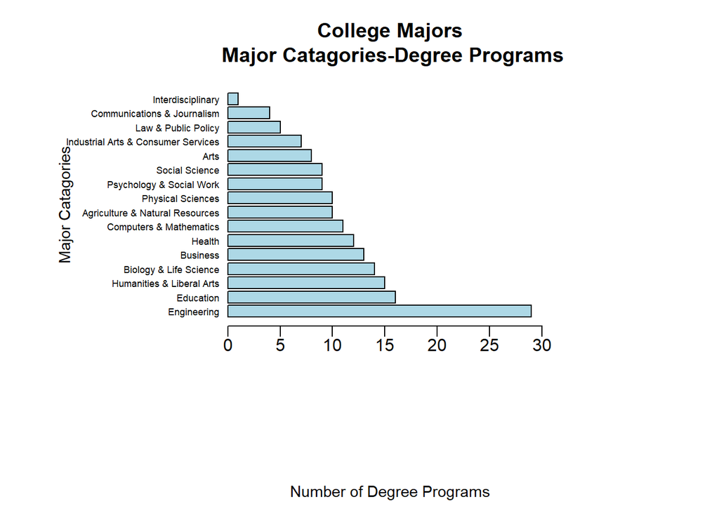

```r
par(mar=c(9,11,4,8)+0.1,mgp=c(7.5,.4,0))
barplot(major_count_table[order(major_count_table,decreasing=TRUE)],
        horiz = TRUE,
        main="College Majors\n Major Catagories-Degree Programs",
        xlab="Number of Degree Programs",
        ylab="Major Catagories",
        las=1,
        xlim = c(0,max(major_count_table, na.rm=TRUE)+2),
        cex.lab = 0.9,
        cex.names = 0.55,
        col='lightblue'
)
```

#### **2.d**

Write the fivethirtyeight data to a csv file. Make sure tht it does not have row labels.

```r
#writing fivethirtyeight database College_recent_grads to a CSV file.

write.csv(df,file="C:/Users/Prodigy/Documents/Personal Info/SMU/MSDS 6306 - Doing Data Science/Unit 4/Assignment/College_Recent_Grads.csv", row.names = FALSE)
```

### Question 3

#### **3.a**

Start a new repository on GitHub for your SMU homework. On your local device, make sure there is a directory for Homework at a minimum; youare welcome to add whatever you would like to this repo in addition to your requirement here.

#### **3.b**

Create a ReadMe.md file which explains the purpose of the repository, the topics included, the sources for the material you post, and contact information in case of questions. Remember, the one in the root directory should be general. You are welcome to make short ReadMes for each assignment individually in other folders.

#### **3.c**

In one (or more) of the nested directories, post your RMarkdown script, HTML file, and data from ‘fivethirtyeight.’ Make sure that in your ReadMe or elsewhere that you credit fifethirtyeight in some way.

#### **3.d**

In your RMarkdown script, please provide the link to this GiHub so the grader can see it.

#### GitHub Repository Link

Link to Repository with RMarkdown, HTML, Data csv and ReadMe files

https://github.com/jlancon/MSDS6306/tree/master/Homework/Unit_4

Unit_4_ReadMe.md Unit_4_Assignment_JLancon.Rmd Unit_4_Assignment_JLancon.Html College_Recent_Grads.csv